# NVD plot data for RSA PD project

A quick overview of the data. There are 2 files, a genus by site/plot matrix “genusmatrix_PA.csv” (object *gdat* below) and ancillary data for each plot “genus_PA_plotdat.csv” (object *d*), which includes plot spatial location, species richness etc. Note that the column “RELEVE_NR” in *d* matches the rownames of *gdat*.

Data cleaning steps implemented so far: 1) Data that had no location confidence information (column Loc_Conf) were excluded (~150 plots).

2. Plots >1km from the coast or borders of SA were excluded (i.e. they won’t fall within any 30s grid environmental data so why bother keeping them…).
3. Plots with no surface area information were excluded.
4. Plots where only a subset of the species were sampled were excluded. There are some subtle differences between the survey protocols used for the plots that remain (“All species present”, “Full floristics”, “Permanently recognisable species”) in that we don’t know if “All species present” and “Full floristics” include or exclude “Seasonally recognizable species” or if the author of the original study gave any thought to the difference…
5. I trimmed the dataset to only the plots in the most common sizes: 16, 25, 50, 100, 200, 400, 900 square metres.
6. I excluded ferns, lichens, lycopods, horsetails and bryophytes (although I may have missed some?).
7. I excluded all alien species I could match with the SAPIA list (~750 listed alien species).

Please let me know if you spot any errors or would like me to change any of the above.

Ok, let’s look at the data

```r
library(ggplot2)
library(maps)
library(maptools)
library(raster)
library(sp)

gdat <- read.csv("/Users/jasper/GIT/VegMapTools/Data/genusmatrix_PA.csv", stringsAsFactors = F, row.names = 1)
d <- read.csv("/Users/jasper/GIT/VegMapTools/Data/genus_PA_plotdat.csv", stringsAsFactors = F, row.names = 1)
```

First off, there is an issue of varying plot size. The number of plots in each size class are indicated below:

```r
summary(as.factor(d$SURF_AREA)) #100m2 looks best...
```

```
##   16   25   50  100  200  400  900
## 2355 1569 1183 5484 2504  732  226
```

How is that split up by biome?

```r
table(d$Biome, d$SURF_AREA)
```

```
##
##                               16   25   50  100  200  400  900
##   Albany Thicket Biome         0    0    0  559    0    0    0
##   Azonal Vegetation          153   19   20  343  190   37   20
##   Forests                      0  127    2   23    0   22    0
##   Fynbos Biome                 6   78  997  333   32   62    0
##   Grassland Biome           2183 1127   66 3211  167  107    0
##   Indian Ocean Coastal Belt    1   27    0   56    2    0    0
##   Nama-Karoo Biome             0   94   45  335   10   99   98
##   Savanna Biome               12   39   53  543 2080  132  108
##   Succulent Karoo Biome        0   52    0    0    0  273    0
##   Waterbodies                  0    0    0    3    0    0    0
```

It seems the most common plot size is 10 x 10m, so it would be easiest if we just went with this? Otherwise we could look at some kind of area scaling, which could add a novel angle to the paper, but could make analyses much more complicated… The only problem with going with 10 x 10m is that there are no plots for SK or Desert biomes…

Here are a couple of figures to give you some idea of what the data look like:

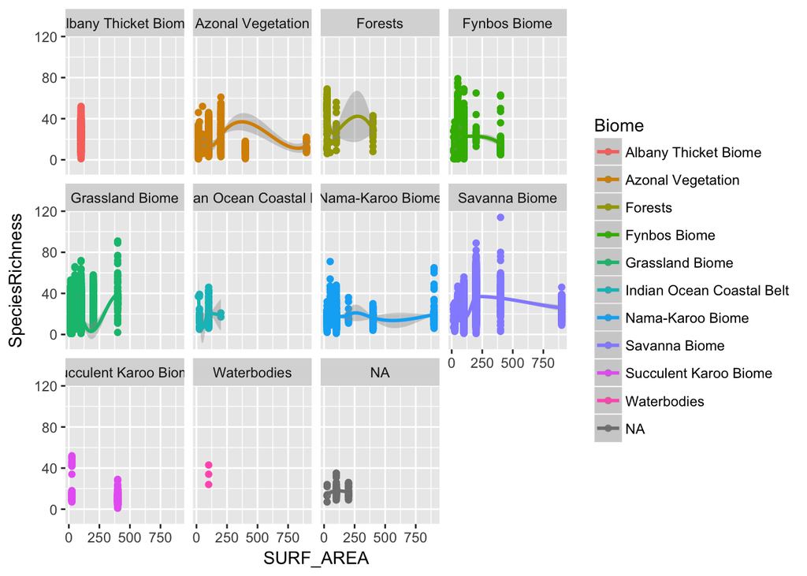

```r
ggplot(data = d, aes(x = SURF_AREA, y = SpeciesRichness, colour = Biome)) + geom_point() + facet_wrap(~Biome) + geom_smooth(method = "loess")
```

Probably looks better as boxplots:

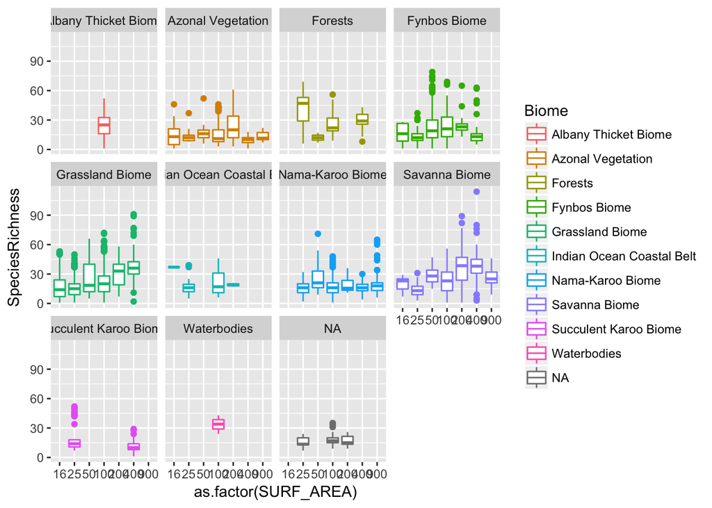

```r
ggplot(data = d, aes(x = as.factor(SURF_AREA), y = SpeciesRichness, colour = Biome)) + geom_boxplot() + facet_wrap(~Biome)
```

# Explore cutoffs for location confidence…

First a summary showing how many plots fall within each location confidence category:

```r
summary(as.factor(d$Loc_Conf))
```

```
##    19    50    75   100   200   250   300   400   500   550   600   700
##  5520   487    88   715   204    72   502    42    31     1   847    13
##  1000  1150  1500  2000  2100  2200  2300  2400  2500  2560  2600  2700
##    17  1113     2   315     1    20     1     1    24   130     3   154
##  2800  3000  3100  3200  3300  3450  3500  3600  3800  4000  4100  4200
##     1   150     2     6     3   277   196     6     1   256    10    12
##  4300  4500  4700  4800  4900  5000  5200  5400  5500  5800  6000  6200
##    22   112     2    18    19    37    41    12    27     6    41     5
##  6300  6700  7000  7500  7800  8000  8400  9000 10000 12000 13000 17000
##   124   148    27   200     7     2     8    38    65   394  1141   129
## 18000 30000 73000
##    98   106     1
```

How many plots with location confidence 5km or less?

```r
sum(d$Loc_Conf<5001)
```

```
## [1] 11433
```

2km or less?

```r
sum(d$Loc_Conf<2001)
```

```
## [1] 9969
```

Some plots in space to check coverage:

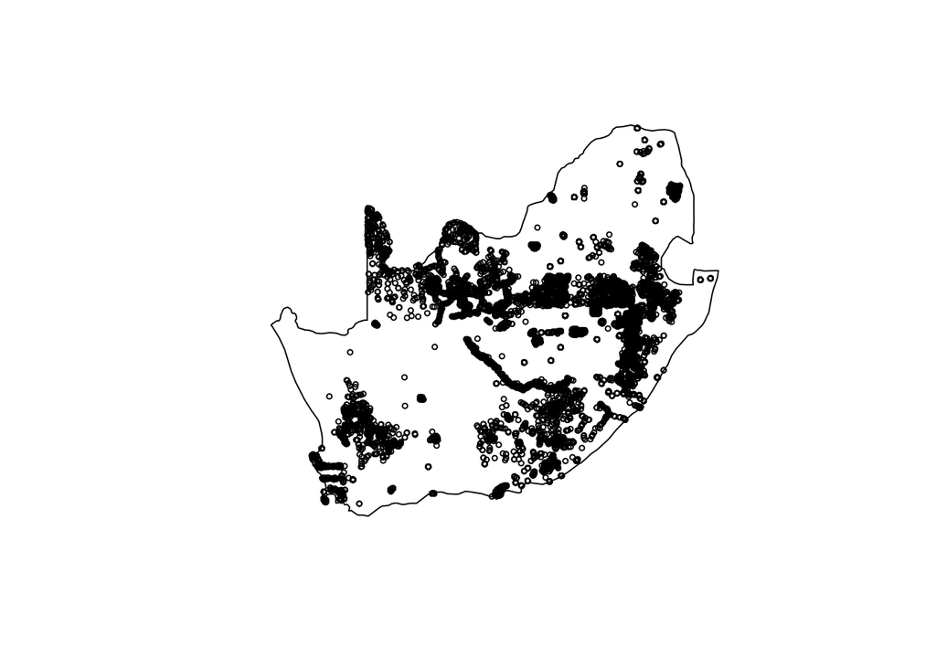

```r
#Make the plots a spatial object and project
spd <- d
coordinates(spd) <- ~ Long + Lat
proj4string(spd) <- "+proj=longlat +datum=WGS84 +no_defs +ellps=WGS84 +towgs84=0,0,0" #Assign a coordinate reference system (Geographic WGS84)

#Get a map of the outline of South Africa
map <- map("world", region = "south africa", fill = TRUE, plot=F)
IDs <- sapply(strsplit(map$names, ":"), function(x) x[1])
map <- map2SpatialPolygons(map, IDs=IDs, proj4string=CRS("+proj=longlat +datum=WGS84 +no_defs +ellps=WGS84 +towgs84=0,0,0"))

#Crop map to the extent of the points
map <- crop(map, extent(spd)+c(-1.5,1,-1,1))
#Plot the map
plot(map)
points(spd, cex=.5)
```